# 2015-02-12-mini-assignment-YuTian.Rmd

Yu Tian

February 12, 2015

## Mini assignment – A visualized analysis of injuries involved in vehicle collisions in NYC.

Load libraries and NYPD data.

```r
library(plotrix)
library(plyr)
library(ggplot2)

setwd("~/Documents/QMSS/2015spring/DataViz/miniassignment/")
crashes <- read.csv('crashes.csv', header=TRUE)
test <- crashes
year=as.numeric (format(as.Date(test$DATE, format ="%m/%d/%Y"),"%Y"))
month=as.numeric (format(as.Date(test$DATE, format ="%m/%d/%Y"),"%m"))
day=as.numeric (format(as.Date(test$DATE, format ="%m/%d/%Y"),"%d"))
test$year <- year
test$month <- month
test$day <- day
```

# I. Total number of different injuries.

The following code calculates total number of different injuries.

```r
injury_type <- cbind(sum(test$NUMBER.OF.PEDESTRIANS.INJURED),sum(test$NUMBER.OF.CYCLIST.INJURED),sum(test$NUMBER.OF.MOTORIST.INJURED))
colnames(injury_type) <- c("PEDESTRIANS","CYCLIST","MOTORIST")
```

1. A bar plot showing total number of different injuries.

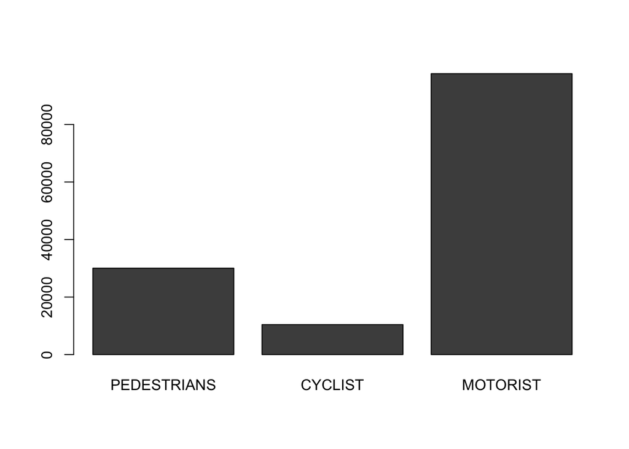

2. A pie chart showing proportion of different injuries.

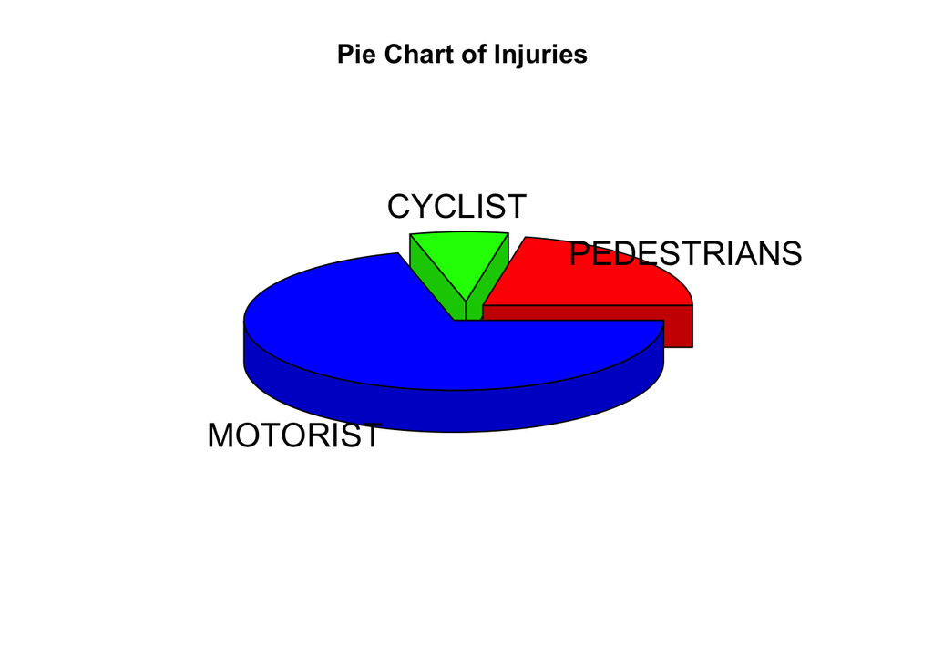

# II. Injuries chaning over time.

In this part, I will use a time series plot to show how rates of different injury types changing over time (daily).

First, use “ddply” “merge” to rearrage into a daily data frame.

```r
PERSONS <- ddply(test, c("DATE","BOROUGH"), summarise, PERSONS = sum(NUMBER.OF.PERSONS.INJURED))
PEDESTRIANS <- ddply(test, c("DATE","BOROUGH"), summarise, PEDESTRIANS = sum(NUMBER.OF.PEDESTRIANS.INJURED))
CYCLIST <- ddply(test, c("DATE","BOROUGH"), summarise, CYCLIST = sum(NUMBER.OF.CYCLIST.INJURED))
MOTORIST <- ddply(test, c("DATE","BOROUGH"), summarise, MOTORIST = sum(NUMBER.OF.MOTORIST.INJURED))

data_daily <- merge(PERSONS,PEDESTRIANS,by=c('DATE','BOROUGH'))
data_daily <- merge(data_daily,CYCLIST,by=c('DATE','BOROUGH'))
data_daily <- merge(data_daily,MOTORIST,by=c('DATE','BOROUGH'))

data_daily$PERCENT.PEDESTRIANS <- data_daily$PEDESTRIANS/data_daily$PERSONS
data_daily$PERCENT.CYCLIST <- data_daily$CYCLIST/data_daily$PERSONS
data_daily$PERCENT.MOTORIST <- data_daily$MOTORIST/data_daily$PERSONS
data_daily$DATE <- as.Date(data_daily$DATE, format ="%m/%d/%Y")

ordered_data <- data_daily[order(data_daily$DATE),]
```

1. A time series plot of total injuries changing over time.

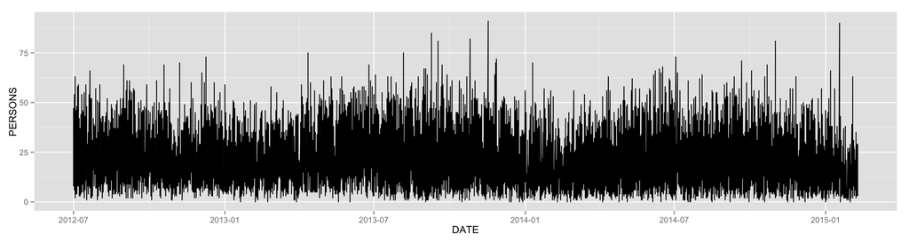

2. A time series plot of pedestrians injury rates from July to September looks like this: (grouped by different subdistricts in New York City)

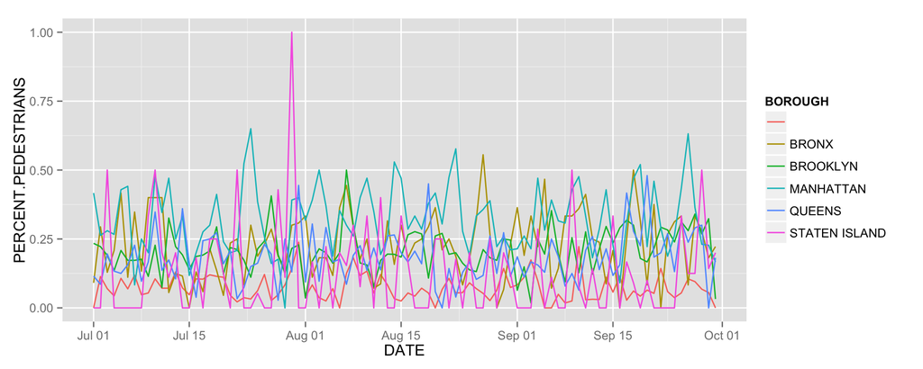

However, the chart is pretty hard to read… So I tried a bunch of different things in the next section.

# III. Stached bars.

The first thing I did is to reshape the data frame to get the monthly injury data for each subdistrict in NYC.

```r
test_data <- test[,c("month","BOROUGH","NUMBER.OF.PERSONS.INJURED","NUMBER.OF.PEDESTRIANS.INJURED","NUMBER.OF.CYCLIST.INJURED","NUMBER.OF.MOTORIST.INJURED")]
PERSONS <- ddply(test_data, c("month","BOROUGH"), summarise, PERSONS = sum(NUMBER.OF.PERSONS.INJURED))
PEDESTRIANS <- ddply(test_data, c("month","BOROUGH"), summarise, PEDESTRIANS = sum(NUMBER.OF.PEDESTRIANS.INJURED))
CYCLIST <- ddply(test_data, c("month","BOROUGH"), summarise, CYCLIST = sum(NUMBER.OF.CYCLIST.INJURED))
MOTORIST <- ddply(test_data, c("month","BOROUGH"), summarise, MOTORIST = sum(NUMBER.OF.MOTORIST.INJURED))
monthly <- merge(PERSONS,PEDESTRIANS,by=c('month','BOROUGH'))
monthly <- merge(monthly,CYCLIST,by=c('month','BOROUGH'))
monthly <- merge(monthly,MOTORIST,by=c('month','BOROUGH'))
```

Now we can use the reorganized data frame to plot stacked bar charts for each type of injury.

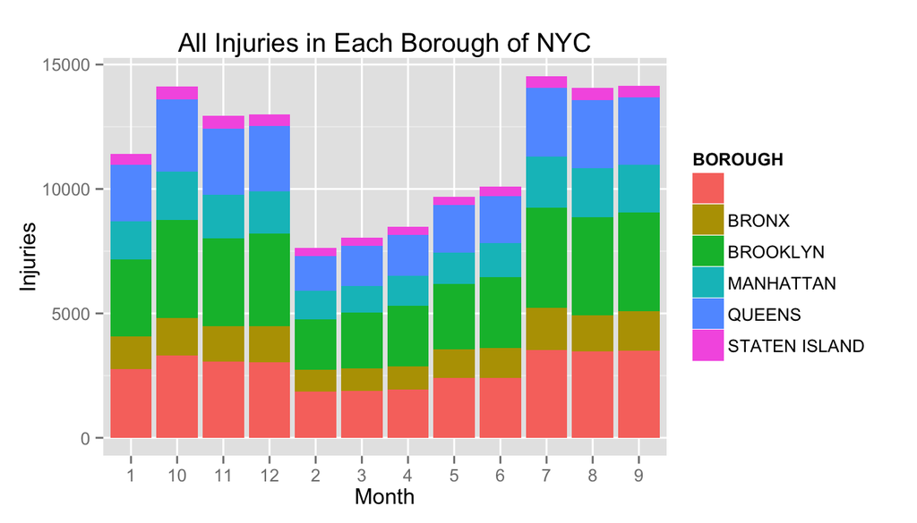

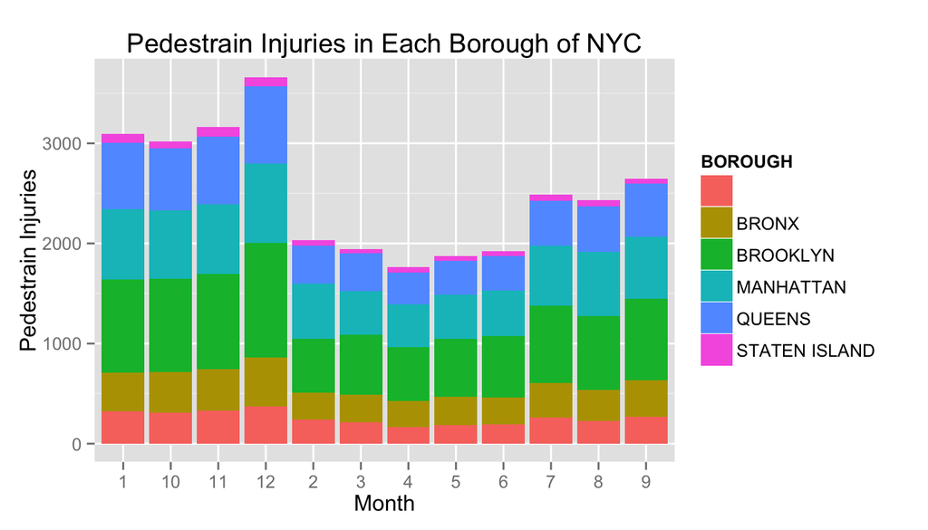

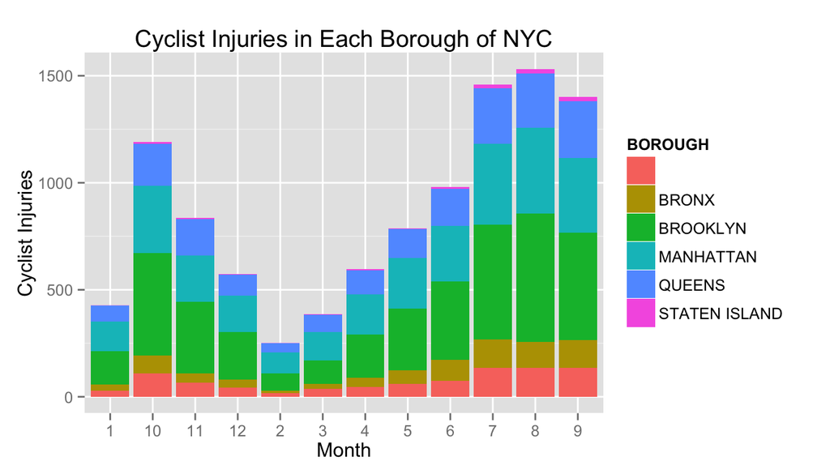

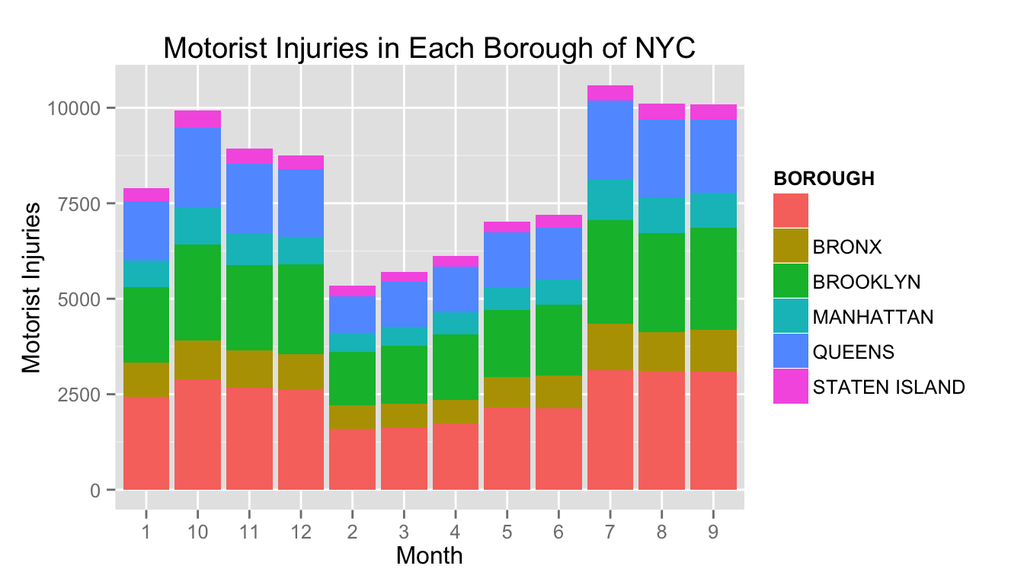